# Stock Analysis

Frank Wang

November 22, 2018

## Stock Analysis Assignment

Download stock data from http://finance.yahoo.com. In this example, we retrieved a year (from April 10, 2017 to April 6, 2018) of data of Apple Inc. (AAPL), saved as `AAPL.csv`.

We used the `read.csv` command to import data and assign them to the object `dat`. Be sure that the file is in the current directory; if not, use the `setwd` command (Under Session/Set Work Directory). The `head` command is for obtaining the first few rows of the data. We show the stock price as a function of time using the `plot` command. Note that the `type` is `l` (el) meaning line not `1` (one).

```r
dat <- read.csv("AAPL.csv")
head(dat)
```

```
##         Date   Open   High    Low  Close Adj.Close   Volume
## 1 2017-04-10 143.60 143.88 142.90 143.17  140.9404 18933400
## 2 2017-04-11 142.94 143.35 140.06 141.63  139.4244 30379400
## 3 2017-04-12 141.60 142.15 141.01 141.80  139.5917 20350000
## 4 2017-04-13 141.91 142.38 141.05 141.05  138.8534 17822900
## 5 2017-04-17 141.48 141.88 140.87 141.83  139.6213 16582100
## 6 2017-04-18 141.41 142.04 141.11 141.20  139.0011 14697500
```

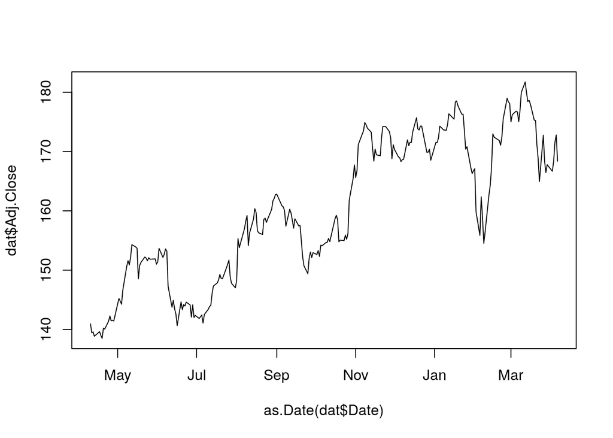

```r
plot(as.Date(dat$Date), dat$Adj.Close, type = "l")
```

We assign the adjusted close to the vector called `close` for later convenience. The number of trading days is the length of the vector, denoted by `n`.

```r
close <- dat$Adj.Close
(n <- length(close))
```

```
## [1] 250
```

In financial news, we often hear relative, or percentage changes. A stock’s rate of return in any time period $t$ is defined as
$$R_{t} = \frac{S_{t} - S_{t-1}}{S_{t-1}}$$
where $S_{t}$ and $S_{t-1}$ are the closing prices at time $t$ and $t-1$, respectively. Below is the calculation.
A histogram is made for the relative changes.

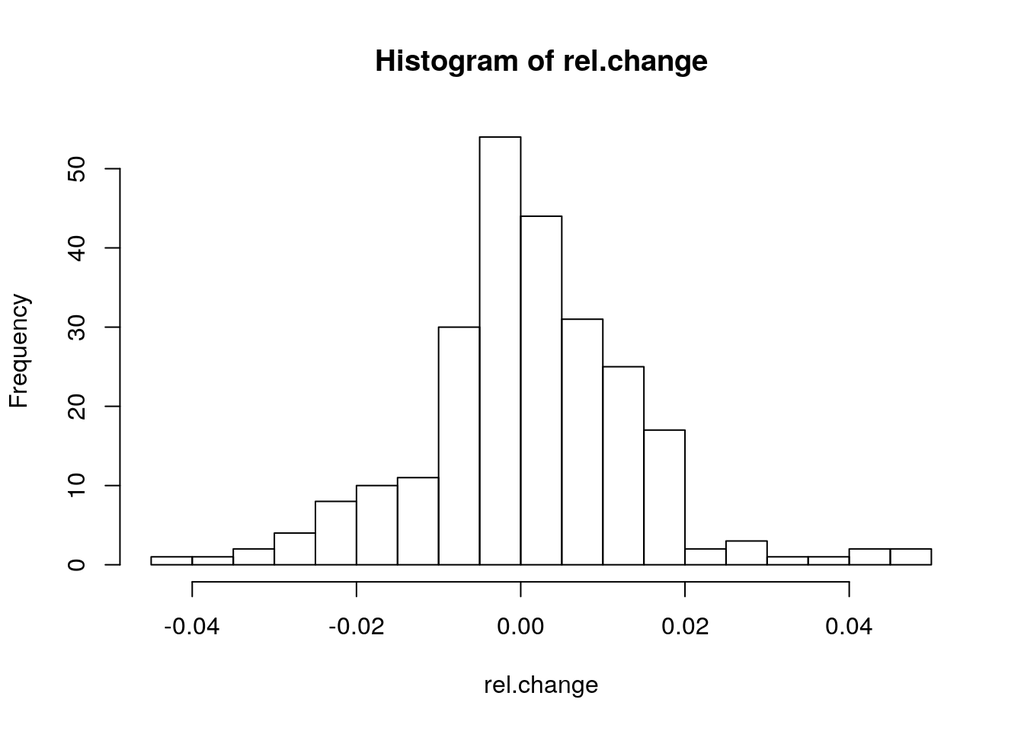

```r
daily.diff <- close[2:n] - close[1:n-1]
rel.change <- daily.diff/close[1:n-1]
hist(rel.change, breaks = 20)
```

We can find the five-number summary and produce a box plot as below.

```r
summary(rel.change)
```

```
##       Min.    1st Qu.     Median       Mean    3rd Qu.       Max.
## -0.0433902 -0.0055524  0.0002952  0.0008015  0.0079969  0.0474718
```

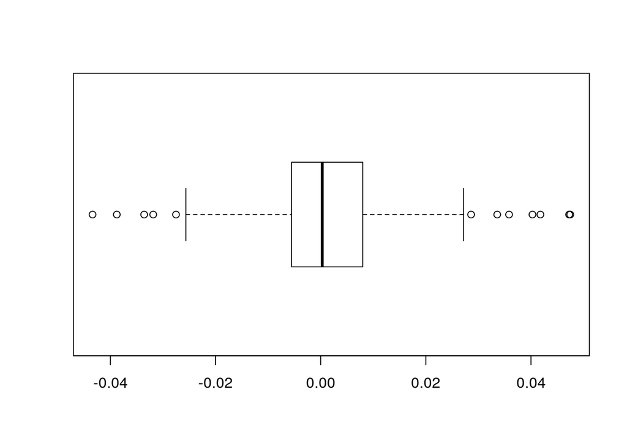

```r
boxplot(rel.change, horizontal = TRUE)
```

To find the mean and standard deviation, use the following commands.

```r
(x.bar <- mean(rel.change))
```

```
## [1] 0.0008014673
```

```r
(stdev <- sd(rel.change))
```

```
## [1] 0.01321591
```

The number of trading day is `n` above

```r
n
```

```
## [1] 250
```

and the number of days when the change is less than the mean is

```r
sum(rel.change < x.bar)
```

```
## [1] 130
```

Express the changes as $z$-scores, and overlay the histogram of $z$ with a standard normal distribution probability density function.

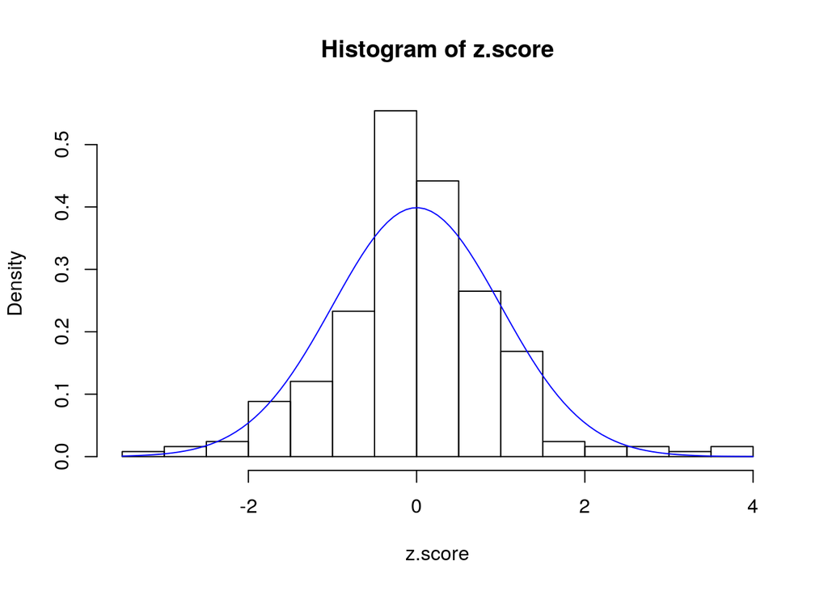

```r
z.score <- (rel.change - mean(rel.change))/sd(rel.change)
hist(z.score, breaks = 20, freq = FALSE)
curve(dnorm(x), col = "blue", add = TRUE)
```

One financial model assumes that stocks advances with geometric Brownian motion,
$$S_{i+1} = S_{i} + \mu S_{i} \Delta t + \sigma S_{i} \epsilon \sqrt{\Delta t}$$
where $\epsilon$ is a random number drawn from a standardized normal distribution.
Use $168.38 as the initial price (the closing value on April 6, 2018), we simulate a possible outcome for the next year. You should re-run this several times to observe the possible outcomes.

```r
S <- c()
close[n]
```

```
## [1] 168.38
```

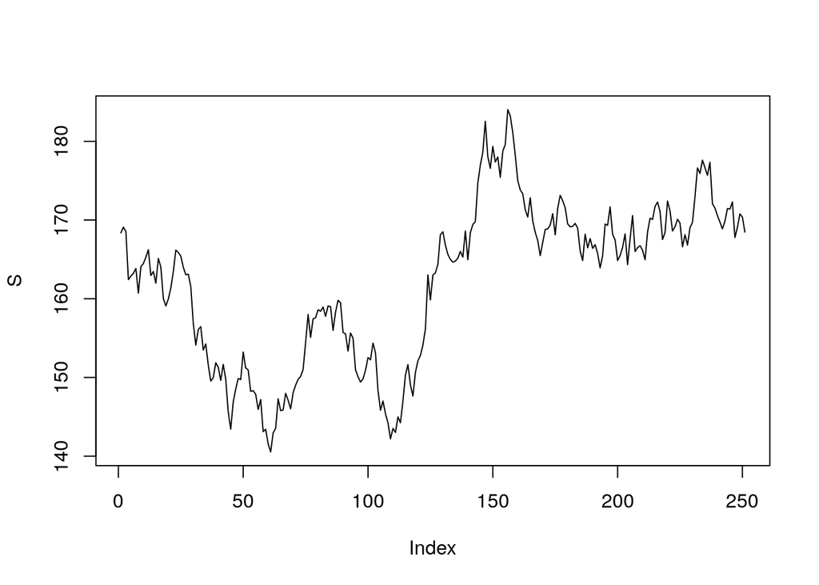

```r
S[1] <- close[n]
for (i in 1:n){
  S[i+1] <- S[i] + x.bar*S[i]*1 + stdev*S[i]*rnorm(1)*sqrt(1)
}
plot(S, type = "l")
```